# Project 3 Slides

November 20, 2016

## Abstract

For our project we chose the following proposal:

"The CEO of a biotech startup is looking for candidates. She is interested in diversifying the workforce in regards to women in STEM (Science, Technology, Engineering, and Math). Where should the startup focus their recruitment and outreach for maximum impact?"

## Introduction

To ensure we use the newest data on recent college graduates we will only consider the most recent datafiles, ignoring older data.

Our approach is to create a scoring system to rank colleges based on where we believe our client will have the most success in recruiting top tier female STEM majors.

## Introduction

We begin by cleaning the data. Since our raw data file contains hundreds of features, we create a new data matrix with only the desired predictors.

We also create several new features by combining columns, which imroves the regression model's interpretability by creating more consise predictors.

## Introduction - Continued

Next we consider a cross-validated linear regression to predict the mean earnings of female students working and not enrolled 6 years after entry using the new data matrix.

We use the mean earnings as a metric to represent the overall quality of a college's graduates, the intuition being that smarter more qualified candidates will be paid more.

## Introduction - Continued

We then use the regression equation, with only the significant terms included, to create a score for each school. After giving each collge a score, we will rank them by said score and present the top institutions to our client.

## Data

For our consultation we consider the following predictors:

MN_EARN_WNE_MALE0_P6 = Mean earnings of female students working and not enrolled 6 years after entry

SATMTMID = Median SAT math score

ADM_RATE = Admission rate

STEM_DEG_WOMEN = Approximate number of female STEM majors

WOMENOONLY = Indicator if schools that are only femal

HIGHDEG4 = Indicator if the school offers Bachelors degrees

COUNT_WNE_MALE0_P6 = Number of female students working and not enrolled 6 years after entry

## Data - Continued

We chose the variables that seemed the most predictable of technical job performance and the variables that were about number of females in technical fields at a school.

The combination of these two types of features will yield the best schools to target (in terms of number of potential recruits as well as recruit's skill level)

## Data Cleaning

In cleaning the data, we decided to remove entries that contained missing values. If there was a missing value of the features we used, we removed that row from the dataset.

Other notable operations we performed on the data to clean it included removing schools that were no longer in operation, removing schools with only male students, and removing schools that specialize in a non-stem field.

## Data Cleaning

We had to change the data type of most columns either to numeric or a factor.

We added in a few columns of our own based off of the information given to us. These included columns such as the percentage of engineering/math/science/tech degrees awarded.

In addition to cleaning the dataset, we also created dummy variables for categorical variables. We also chose to mean center and standardize our variables to allow for accurate predictions and more straight-forward analysis.

## Data Exploration

To initially explore the data, we first broke up the dataset into general data, including:

ADM_RATE

SATMTMID

UGDS_WOMEN

MN_EARN_WNE_MALE0_P6

COUNT_WNE_MALE0_P6

## Data Exploration

We note several interesting statistics:

The first being that the average admission rate is \(0.647\), which is for colleges in general.

To turn our attention to focus on the data we have on women, we look at the number of undergrads enrolled in schools. The mean is actually above \(0.50\), indicating that more than half of the student body is made up of women.

## Data Exploration

The mean earnings of women after 6 years of graduating hovers at around $34,000, while the maximum earnings reach $100,100.

We note the high range of salaries, with a range of almost $80,000. The number of females working after 6 years is on average 1,000 and also has a relatively high range of 8,650.

## Data Exploration

The histogram of the percentage of women in undergrad is a visualization of the fact that there are over 0.50 women in most undergraduate student bodies.

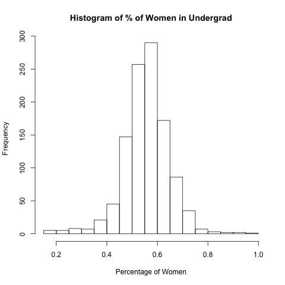

## Data Correlation

We wanted a way to see the relationships between variables in this dataset.

## Scatterplot Matrix

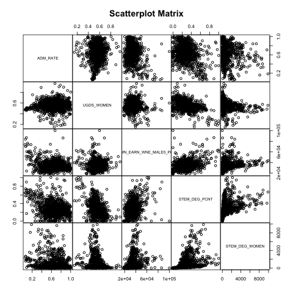

## Methods

In order to properly consult our client, we build score function and apply it to each school, recommending the top institutions to our client.

To create the score function we use ordinary least squares regression (OLS) and cross validation.

## Analysis

After running our regression script we observed the following values for our \(\hat{\beta}_{OLS}\) estimator:

Predictor Significance

|  | Estimate | Std. Error | t value | Pr(>\|t\|) |
| --- | --- | --- | --- | --- |
| (Intercept) | -0.00 | 0.02 | -0.00 | 1.00 |
| ADM_RATE | -0.07 | 0.03 | -2.77 | 0.01 |
| SATMTMID | 0.61 | 0.03 | 21.75 | 0.00 |
| STEM_DEG_WOMEN | -0.15 | 0.03 | -5.05 | 0.00 |
| COUNT_WNE_MALE0_P6 | 0.15 | 0.03 | 5.44 | 0.00 |
| WOMENONLY | 0.06 | 0.02 | 2.49 | 0.01 |
| HIGHDEG4 | 0.21 | 0.02 | 8.55 | 0.00 |

All the regressors are significant so we will utilize all values except the intercept in our score function.

## Results

From our \(10\)-fold cross validation we observe a mean squared error of: 0.6064

Next we build the score function, utilizing the \(\hat{\beta}_{OLS}\) values we found as the weights for our function. This yields the following expression:

f(X\(_{\cdot,i})\) (-0.0715) X\(_{1,i}\) + 0.6094 X\(_{2,i}\) + (-0.1537) X\(_{3,i}\) + 0.1469 X\(_{4,i}\) + 0.0582 X\(_{5,i}\) + 0.2076 X\(_{6,i}\)

## Results - Continued

Where \(X_{j,i}\) represents the j-th regressor value from our OLS regression of the i-th observation in the data matrix. Using this equation, we apply it to all schools in our data matrix and sort by their relative score to yield the top 10 colleges we recomend the client recruits from

## Results - Continued

Top 10 Colleges to Recruit From

| SCORE | INSTNM | CITY |
| --- | --- | --- |
| 2.14 | Massachusetts Institute of Technology | Cambridge |
| 2.06 | University of Chicago | Chicago |
| 2.04 | Washington University in St Louis | Saint Louis |
| 2.04 | Yale University | New Haven |
| 2.03 | Vanderbilt University | Nashville |
| 2.02 | Harvard University | Cambridge |
| 2.01 | Princeton University | Princeton |
| 1.99 | Rice University | Houston |
| 1.98 | Columbia University in the City of New York | New York |
| 1.96 | Northwestern University | Evanston |

## Recommedations

After preforming a preliminary examination of the data, building the previously detailed OLS regression model, and building our score function, we recommend our client recruit from the top 10 schools given in the previous slide.

It should be noted that our score function is derrived from our regression model, with the coefficients used were the same \(\beta\) values becoming the weights in the function. Using this data, we are sure our client will be able to recruit highly qualified female STEM majors for her company.